# Duração e presença feminina entre os 1º lugares da Billboard Hot 100

Novembro de 2026

## A pergunta

Como mudaram, ao longo das décadas, as músicas que chegaram ao **1º lugar** da Billboard Hot 100?

- Qual a **duração média** dessas músicas em cada período?
- Qual a **proporção de semanas** com uma **artista mulher** no topo?

Período estudado: **04/08/1958 a 17/10/2026**

## População e unidade elementar

- **População:** todas as semanas da Billboard Hot 100 no período → **N = 3.560 semanas**
- **Unidade elementar:** a **semana**, representada pela música em 1º lugar
- Uma música que ficou 10 semanas no topo conta **10 vezes**: o foco é a música mais popular de cada semana
- **Quadro amostral:** a lista completa das semanas (`top_hits_number_one.csv`)
- **Variáveis:** duração da música (s) e gênero do artista principal

## Estratos: oito períodos

| Período | Semanas (N_h) | Amostra (n_h) | Prob. de seleção (n_h/N_h) |
| --- | --- | --- | --- |
| 1958–59 | 74 | 30 | 0.405 |
| 1960s | 521 | 30 | 0.058 |
| 1970s | 522 | 30 | 0.057 |
| 1980s | 522 | 30 | 0.057 |
| 1990s | 521 | 30 | 0.058 |
| 2000s | 522 | 30 | 0.057 |
| 2010s | 523 | 30 | 0.057 |
| 2020–26 | 355 | 30 | 0.085 |

## Plano amostral

- **Amostragem aleatória estratificada**, em um único estágio
- Em cada período: **AAS sem reposição de 30 semanas**, sorteios independentes (semente 2026)
- **Alocação igual** → precisões parecidas, o que facilita comparar os períodos
  - Proporcional deixaria 1958–59 com apenas ~5 semanas
- **Tamanho:** n = 240 semanas, definido pelo **tempo disponível** para a coleta
  - Para margens de 10 s e 10 p.p., seriam necessárias ~650 semanas
- Cada período é estimado **separadamente**, sem estimativa combinada

## Coleta dos dados

- **Após o sorteio**, só para as **198 músicas** das semanas sorteadas
- **Consulta automatizada (API)** à base MusicBrainz, feita em R
  - Duração: mediana das gravações da música
  - Gênero: cadastro do artista
- **Revisão manual** do que faltou ou ficou ambíguo
  - 9 durações (Wikipedia) e 96 classificações de gênero
- **Critérios de gênero**
  - Artista principal = **primeiro nome creditado**
  - Grupo conta como mulher só se for **só de mulheres**

## Estimação (em cada período h)

**Duração média**

\[\bar{y}_h = \frac{1}{n_h}\sum_{i=1}^{n_h} y_{hi}, \qquad \widehat{\mathrm{Var}}(\bar{y}_h) = (1 - f_h)\,\frac{s_h^2}{n_h}\] IC 95%: \(\;\bar{y}_h \pm t_{29;\,0{,}025}\sqrt{\widehat{\mathrm{Var}}(\bar{y}_h)}\)

**Proporção de artistas mulheres**

\[\hat{P}_h = \frac{1}{n_h}\sum_{i=1}^{n_h} y_{hi}, \qquad \widehat{\mathrm{Var}}(\hat{P}_h) = (1 - f_h)\,\frac{\hat{P}_h(1 - \hat{P}_h)}{n_h - 1}\] IC 95%: \(\;\hat{P}_h \pm 1{,}96\sqrt{\widehat{\mathrm{Var}}(\hat{P}_h)}\) · com \(f_h = n_h/N_h\) (correção para população finita)

## Resultado: duração média

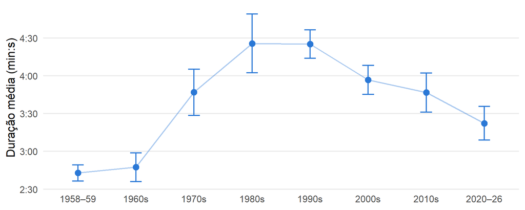

As músicas ficaram **~1min40s mais longas** até os anos 80/90 e depois **encurtaram**: os intervalos não se sobrepõem

## Resultado: artistas mulheres

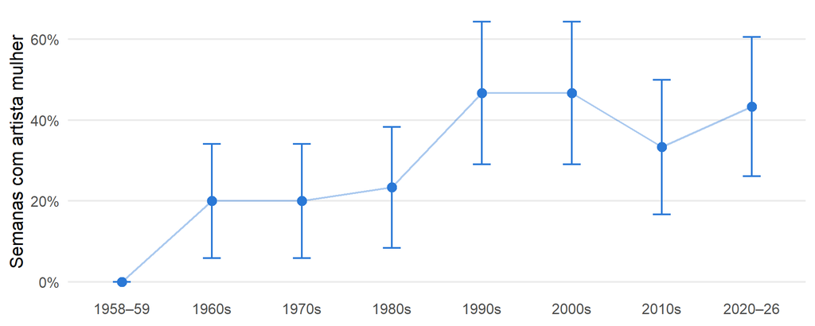

De **~20%** (1960–1989) para **33% a 47%** a partir dos anos 90, mas com margens de **14 a 18 p.p.**

## Limitações

- **Margens maiores que o desejado:** 30 semanas por período (tempo disponível)
  - Duração: ±6 a ±23 s · Proporção: ±14 a ±18 p.p.
- **Versões de álbum:** a base às vezes registra uma versão mais longa que o single
  - Tende a **superestimar** a duração, sobretudo nos anos 70 e 80
- **Participações (*featuring*)** não contam
  - Tende a **subestimar** a presença feminina nas décadas recentes
- **A parada mudou:** de vendas e rádio para *streaming*

## Conclusão

- A **duração média** cresceu até os anos 80/90 (~4min25s) e depois caiu (~3min22s hoje)
- A **presença feminina** no 1º lugar aumentou a partir dos anos 90
- As tendências se mantêm mesmo considerando as limitações

**Obrigado!**